# The mapping from signaling and drug response

# Introduction

In our experiments, viabilities are measured in a 3-day CellTiter-Blue assay, while signaling responses are measured in the Luminex 2 hours after drug perturbation. Here, we test to what extend differences in viability can be predicted from the measured signaling response, and parametrize this relation.

```
## here() starts at /Users/evertbosdriesz/Documents/GitHub/cnr-selective-combos
```

# Data preparation

The signaling model fits/predicts log2-fold changes in nodes in response to perturbations, so we’ll only consider those.

```r
wt_lum_lfc <- read_tsv(here("results", "perturbations", "wt-luminex-lfc.tsv"))
pi3k_lum_lfc <- read_tsv(here("results", "perturbations", "pi3k-luminex-lfc.tsv"))

wt_lum_abs <- read_tsv(here("results", "perturbations", "wt-luminex.tsv"))
pi3k_lum_abs <- read_tsv(here("results", "perturbations", "pi3k-luminex.tsv"))

wt_env <- read_tsv(here("results", "perturbations", "wt-envision.tsv"))
pi3k_env <- read_tsv(here("results", "perturbations", "pi3k-envision.tsv"))
```

First, we prepare the data-frame dat_lfc, containing the log2 fold-changes of each epitope together with the Viabilities. The FGFRi treatments are discarded in the network reconstruction, so we’ll also not include it here.

```r
wt <- left_join(
  wt_env %>%
    group_by(Treatment) %>%
    summarise(Viability = mean(NormalizedViability)),
  wt_lum_lfc %>%
    gather(Treatment, val, -Epitope) %>%
    spread(Epitope, val),
  by = "Treatment"
)

pi3k <- left_join(
  pi3k_env %>%
    group_by(Treatment) %>%
    summarise(Viability = mean(NormalizedViability)),
  pi3k_lum_lfc %>%
    gather(Treatment, val, -Epitope) %>%
    spread(Epitope, val),
  by = "Treatment"
)

dat_lfc <- bind_rows(list("WT" = wt, "PI3K" = pi3k), .id = "Cell") %>%
  filter(!is.na(Akt1)) %>%
  filter(!str_detect(Treatment, 'FGFRi')) %>% # Remove treatments not used in signaling model
  mutate(Cell = factor(Cell, levels = c("WT", "PI3K")))
rm(wt, pi3k)


paged_table(head(dat_lfc))
```

| Cell | Treatment | Viability | Akt1 | BioAkt | CREB1 | EGFR | ERK1 | GSK3 | MEK1 | P70S6K | PRAS40 | RS6 |
| --- | --- | --- | --- | --- | --- | --- | --- | --- | --- | --- | --- | --- |
| WT | AKTi 1uM | 0.4522555 | 0.16186662 | -7.852861 | 0.03291050 | -0.1952628 | -0.01939538 | -0.08843296 | 0.053027977 | -0.1839213 | -0.7484507 | -0.12779749 |
| WT | AKTi 1uM + mTORi 0.01uM | 0.2519288 | -0.37577510 | -5.816936 | -0.07833529 | -0.3708206 | -0.25907710 | -0.33580994 | -0.003230024 | -0.6095931 | -1.5550676 | -0.28977597 |
| WT | AKTi 5uM | 0.1414615 | -0.38485440 | -8.088295 | -0.17873088 | -0.5566486 | -0.26172912 | -0.44634642 | -0.087854959 | -0.7024417 | -1.0814662 | -0.47339926 |
| WT | EGFRi 0.3uM | 0.4488448 | -0.03936837 | -1.472275 | -0.11196727 | -0.4316131 | -1.74862004 | -0.26895751 | -1.118404088 | -0.1538129 | -0.2064101 | 0.09976721 |
| WT | EGFRi 0.3uM + AKTi 1uM | 0.4593542 | -0.32874449 | -7.696475 | -0.16960959 | -0.8916884 | -1.38197677 | -0.72195037 | -0.781103789 | -0.5408024 | -1.1897191 | -0.15957456 |
| WT | EGFRi 0.3uM + ERKi 0.02uM | 0.1421087 | -0.13479954 | -1.810762 | -0.22909823 | -0.9226956 | -1.98559375 | -0.59087826 | -1.181925394 | -0.3543055 | -0.2025097 | -0.27406839 |

# Correlations between log2 fold change and viability

A first simple approach is to look at the correlations between Epitopes and Inhibition.

We see a pretty nice negative correlation between the log2-fold change in pAKT and pERK, and drug efficacy. However, none of the nodes is very predictive for viabilty by itself.

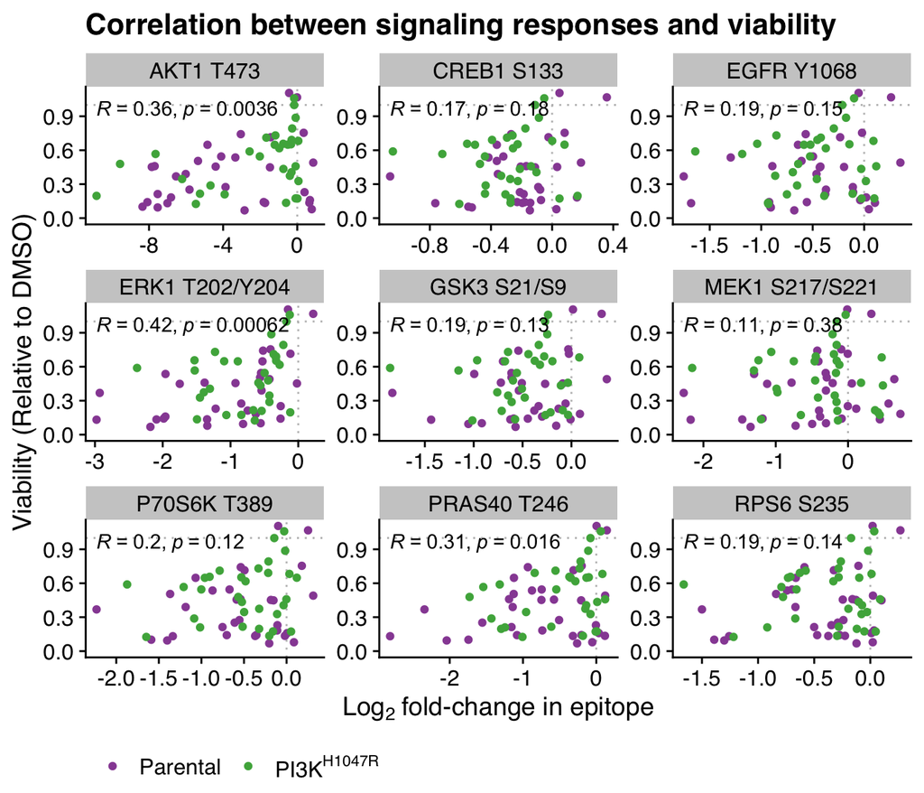

```r
ggplot(
  filter(
    gather(dat_lfc, Epitope, LFC, -Cell, -Treatment, -Viability),
    Epitope != "Akt1"
  ),
  aes(x = LFC, y = Viability)) +
  geom_vline(xintercept = 0, color = "gray", linetype="dotted") +
  geom_hline(yintercept = 1, color = "gray", linetype="dotted") +
  expand_limits(y = c(0, 1)) +
  geom_point(aes(color = Cell)) +
  scale_color_manual(
    name = "",
    breaks = c("WT", "PI3K"),
    values = color_lst,
    labels = label_lst
  ) +
  labs(
    title = "Correlation between signaling responses and viability",
    x = bquote("Log"[2]~"fold-change in epitope"), y = "Viability (Relative to DMSO)"
  ) +
  facet_wrap(~Epitope, scales = "free", labeller = as_labeller(epitope_labels)) +
  cowplot::theme_cowplot(font_family = "Helvetica") +
  ggpubr::stat_cor(method = "pearson") +
  theme(legend.position = "bottom")
```

```r
plt <- ggplot(
  filter(
    gather(dat_lfc, Epitope, LFC, -Cell, -Treatment, -Viability),
    Epitope %in% c("BioAkt", "ERK1")
  ),
  aes(x = LFC, y = Viability, color = Cell)) +
  geom_vline(xintercept = 0, color = "gray", linetype="dotted") +
  geom_hline(yintercept = 1, color = "gray", linetype="dotted") +
  expand_limits(y = c(0, 1)) +
  geom_point() +
  labs(
    #title = "Correlation between signaling responses and viability",
    x = bquote("Log"[2]~"fold-change in epitope"), y = "Viability (Relative to DMSO)"
  ) +
  facet_wrap(~Epitope, scales = "free", labeller = as_labeller(epitope_labels)) +
  scale_color_manual(name = "", values = color_lst, labels = label_lst) +
  cowplot::theme_cowplot(font_family = "Helvetica", font_size = 6) +
  theme(legend.position = "bottom")

plt + labs(title = "Correlation between signaling responses and viability")
```

[output not shown]

ERK1 and AKT have the strongest correlation with inhibition.

```r
dat_lfc %>%
  summarise_if(is.double, funs(cor(., dat_lfc[, "Viability"]))) %>%
  gather(Epitope, Correlation) %>%
  filter(Epitope != "Viability") %>%
  arrange(desc(Correlation)) %>%
  paged_table()
```

| Epitope | Correlation |
| --- | --- |
| ERK1 | 0.4225621 |
| BioAkt | 0.3645246 |
| PRAS40 | 0.3057679 |
| P70S6K | 0.2021991 |
| Akt1 | 0.1997818 |
| GSK3 | 0.1930081 |
| RS6 | 0.1904531 |
| EGFR | 0.1854422 |
| CREB1 | 0.1718414 |
| MEK1 | 0.1126485 |

# Exploration using Linear model

Next, let’s see how well we can predict inhibition from short-term signaling responses using a linear model.

We first fit a linear model using all Epitopes. We remove the intercept because in the absence of any deviation in signaling activity, viability should be equal to that of DMSO control and hence inhibition should be 0.

```r
fit_lm_all <-
  dat_lfc %>%
    mutate(dat_lfc, Inhibition = 1 - Viability) %>%
    select(-Treatment, -Akt1, -Cell, -Viability) %>%
  lm(
  formula = Inhibition ~ 0 + .,
  data = .)

summary(fit_lm_all)
```

```
##
## Call:
## lm(formula = Inhibition ~ 0 + ., data = .)
##
## Residuals:
##      Min       1Q   Median       3Q      Max
## -0.34469 -0.08308  0.02371  0.15749  0.49149
##
## Coefficients:
##        Estimate Std. Error t value Pr(>|t|)
## BioAkt -0.06512    0.02145  -3.036 0.003710 **
## CREB1   0.29030    0.29276   0.992 0.325910
## EGFR    0.06946    0.21745   0.319 0.750644
## ERK1   -0.57542    0.05088 -11.310 9.56e-16 ***
## GSK3   -0.20009    0.28353  -0.706 0.483473
## MEK1    0.45957    0.12039   3.817 0.000355 ***
## P70S6K  0.14995    0.17213   0.871 0.387606
## PRAS40  0.10783    0.12299   0.877 0.384617
## RS6    -0.37240    0.21295  -1.749 0.086114 .
## ---
## Signif. codes:  0 '***' 0.001 '**' 0.01 '*' 0.05 '.' 0.1 ' ' 1
##
## Residual standard error: 0.2142 on 53 degrees of freedom
## Multiple R-squared:  0.8959, Adjusted R-squared:  0.8782
## F-statistic: 50.68 on 9 and 53 DF,  p-value: < 2.2e-16
```

We get a surprisingly good fit (R-squared ~ 0.9, although this is lower when an intercept is included, not shown). ERK1, BioAkt and MEK1 are significant predictors. BioAkt and ERK1 have the expected, negative, sign. BioAkt has a small coefficient, due to it’s generally large LFCs. MEK1 has a positive sign. However, MEK1 is highly correlated with ERK1 (pearson correlation = 0.8130455), so that doesn’t mean much.

How well does a model only containing ERK1 and BioAkt fit the data?

```r
fit_lm_erkakt <- lm(
  formula = Inhibition ~  0 + BioAkt + ERK1,
  data = mutate(dat_lfc, Inhibition = 1 - Viability))

summary(fit_lm_erkakt)
```

```
##
## Call:
## lm(formula = Inhibition ~ 0 + BioAkt + ERK1, data = mutate(dat_lfc,
##     Inhibition = 1 - Viability))
##
## Residuals:
##     Min      1Q  Median      3Q     Max
## -0.7028 -0.0291  0.1273  0.2458  0.5495
##
## Coefficients:
##         Estimate Std. Error t value Pr(>|t|)
## BioAkt -0.059561   0.009801  -6.077 9.14e-08 ***
## ERK1   -0.322402   0.036866  -8.745 2.65e-12 ***
## ---
## Signif. codes:  0 '***' 0.001 '**' 0.01 '*' 0.05 '.' 0.1 ' ' 1
##
## Residual standard error: 0.2822 on 60 degrees of freedom
## Multiple R-squared:  0.7955, Adjusted R-squared:  0.7887
## F-statistic: 116.7 on 2 and 60 DF,  p-value: < 2.2e-16
```

Still very well, with an R-squared ~ 0.8

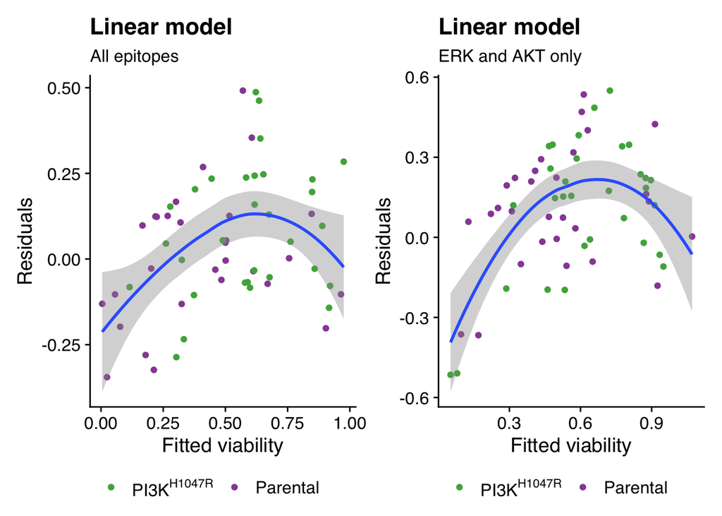

```r
p_res_linfull <-
  ggplot(
    filter(left_join(broom::augment(fit_lm_all), dat_lfc), .fitted < 1.),
    aes(x = 1-.fitted, y = .resid)) +
    geom_point(aes(color = Cell)) +
    geom_smooth(span = 1) +
    scale_color_manual(name = "", values = color_lst, labels = label_lst) +
    cowplot::theme_cowplot(font_family = "Helvetica") +
    theme(legend.position = "bottom") +
    labs(titles = "Linear model", subtitle = "All epitopes",
         x = "Fitted viability", y = "Residuals")

p_res_lin <-
  ggplot(
    filter(left_join(broom::augment(fit_lm_erkakt), dat_lfc), .fitted < 1.),
    aes(x = 1-.fitted, y = .resid)) +
    geom_point(aes(color = Cell)) +
    geom_smooth(span = 1) +
    scale_color_manual(name = "", values = color_lst, labels = label_lst) +
    cowplot::theme_cowplot(font_family = "Helvetica") +
    theme(legend.position = "bottom") +
    labs(title = "Linear model", subtitle = "ERK and AKT only",
         x = "Fitted viability", y = "Residuals")

p_res_linfull + p_res_lin
```

```r
ggsave(
  here("figures/correlations-and-predictions/residuals-fitted-linear.pdf"),
  p_res_lin +
    cowplot::theme_cowplot(font_family = "Helvetica", font_size = 6) +
    theme(legend.position = "bottom"),
  width = 2, height = 3)

ggsave(
  here("figures/correlations-and-predictions/residuals-fitted-linear-full.pdf"),
  p_res_linfull +
    cowplot::theme_cowplot(font_family = "Helvetica", font_size = 6) +
    theme(legend.position = "bottom"),
  width = 2, height = 3)
```

# Non-linear transfer functions

We saw that a linear regression of ∆pAKT1 and ∆pERK1 gave a reasonable fit, but also that a non-linear “activation function” for the viability might make more sense. We’ll test this next.

Specifically, we’ll test the following transfer functions. These are designed such that when ERK1 or AKT1 are at their DMSO level (∆AKT or ∆ERK = 0), the viability is 1, and when they go to 0 (∆AKT or to -$\infty$) the viability is 0:

1. Michelis-Menten like: $\mathrm{viability} \sim \frac{1}{1 - \Delta ERK1/KM_{ERK1} - \Delta AKT/KM_{AKT}}$. This has the disadvantage that it becomes unstable for positive ∆ERK and ∆AKT (especially as these approach their KM). However, in all perturbations we tested, we find very few instances where these are positive.
2. MM-multiplicative: $\mathrm{viability} \sim 1 / \left(1 - \frac{\Delta AKT}{KM_{AKT}}\right)\left(1 - \frac{\Delta ERK}{KM_{ERK}}\right)$. Similar as above, but with multiplicative effects of the inhibitors.
3. Logistic-like: $\mathrm{viability} \sim \frac{2}{1+2^{\Delta ERK/KM_{ERK}}} * \frac{2}{1+2^{\Delta AKT/KM_{AKT}}}$, with ∆ERK and ∆AKT being the log2-fold changes. This function models the viability as the product of logistic-like curves for each epitope. It is normalized such that the viability is 1 when ∆ERK and ∆AKT are 0. For large, positive values of ∆AKT or ∆ERK this function will asymptotically approach 4, which is biologically unlike. Hence, it is only a useful function for (predominantly) negative fold-changes.
4. Logistive-additative: $\mathrm{viabilty} \sim \frac{3}{1+2^{-\Delta ERK/KM_{ERK}} +2^{-\Delta AKT/KM_{AKT}}}$, similar as above, but with additative instead of multiplicative effects of ERK and AKT inhibition.

To properly test all transfer functions (including the linear ones), wel compare them using a leave-one-out cross-validation.

## Model selection using model fit and LOO cross-validation

```r
formula_lin <- 1-Viability ~ 0 + ERK1 + BioAkt

formula_mm_mult <- Viability ~ 1 / ((1 - ERK1 / KM_ERK1) * (1 - BioAkt / KM_BioAkt))
formula_mm  <- Viability ~ (1/(1 + -ERK1 / KM_ERK1 + -BioAkt / KM_BioAkt))

formula_log <- Viability ~ 4 / ((1 + 2^(-ERK1 / KM_ERK1)) * (1 + 2^-(BioAkt / KM_BioAkt)))
formula_log_add  <- Viability ~ 3 / ((1 + 2^(-ERK1 / KM_ERK1) + 2^-(BioAkt / KM_BioAkt)))
```

We will first fit all models to the data and consider the residual standard error.

```r
lst_formula <- c("MM" = formula_mm, "MM_mult" = formula_mm_mult,
                 "log" = formula_log, "log_add" = formula_log_add)

fits_wt <-
  map(lst_formula,
  function(x) {
    nls(formula = x,
      data = filter(dat_lfc, Cell == "WT"),
      start = list("KM_ERK1" = 0.5, "KM_BioAkt" = 2.5))
  }
)

fits_pi3k <-
  map(lst_formula,
  function(x) {
    nls(formula = x,
      data = filter(dat_lfc, Cell == "PI3K"),
      start = list("KM_ERK1" = 0.5, "KM_BioAkt" = 2.5))
  }
)

df_sigma <-
  bind_rows(
  "WT" = as_tibble(map(fits_wt, sigma)),
  "PI3K" = as_tibble(map(fits_pi3k, sigma)),
  .id = "Cell"
  ) %>%
  pivot_longer(-Cell, names_to = "Formula", values_to = "sigma") %>%
  group_by(Formula) %>%
  summarise(mean_residual_standard_error = mean(sigma)) %>%
  add_row(Formula = "lm_full", mean_residual_standard_error = sigma(fit_lm_all)) %>%
  add_row(Formula = "lm_erk_akt", mean_residual_standard_error = sigma(fit_lm_erkakt))

df_sigma %>%
  arrange(mean_residual_standard_error)
```

| Formula | mean_residual_standard_error |
| --- | --- |
| MM | 0.1973205 |
| MM_mult | 0.2047775 |
| log_add | 0.2068038 |
| log | 0.2100405 |
| lm_full | 0.2142366 |
| lm_erk_akt | 0.2822036 |

```r
subtitle_mm <- expression(
  "Viability ~ " * frac("1","[1 + -"*Delta*"AKT/KM"[AKT] * " + -"
  * Delta*"ERK1/KM"[ERK] * "]"))


fit_mm_wt  <- nls(
  formula_mm, filter(dat_lfc, Cell == "WT"),
  start = list("KM_ERK1" = 0.5, "KM_BioAkt" = 2.5)
  )

fit_mm_pi3k  <- nls(
  formula_mm, filter(dat_lfc, Cell == "PI3K"),
  start = list("KM_ERK1" = 0.5, "KM_BioAkt" = 2.5)
  )


p_res_mm <-
  bind_rows(
  "PI3K" = broom::augment(fit_mm_pi3k), "WT" = broom::augment(fit_mm_wt),
  .id = "Cell"
  ) %>%
  filter(.fitted < 1) %>%
  ggplot(aes(x = .fitted, y = .resid)) +
    geom_point(aes(color = Cell)) +
    geom_smooth(span = 1) +
    scale_color_manual(name = "", values = color_lst, labels = label_lst) +
    cowplot::theme_cowplot(font_family = "Helvetica") +
    theme(legend.position = "bottom") +
    labs(title = "Michaelis-Menten like", subtitle = subtitle_mm,
         x = "Fitted viability", y = "Residuals")

ggsave(
  here("figures/correlations-and-predictions/residuals-fitted-mm.pdf"),
  p_res_mm +
    cowplot::theme_cowplot(font_family = "Helvetica", font_size = 6) +
    theme(legend.position = "bottom"),
  width = 2, height = 3)
```

How does this compare to the linear models? Let’s do a leave one out cross validation to find out.

```r
# Function to perform the model fitting
get_loo_results <- function(splits, formula, starts = NA, grouped = FALSE,
                            method = "nls", maxiter = 100){
  # Get the analysis data
  dat <- rsample::analysis(splits)

  # Remove data not matching the assesment cell line
  if (grouped) {
    dat <- filter(dat, Cell == rsample::assessment(splits)$Cell)
  }
  # Train the model
  if (method == "nls") {
    mod <- nls(formula = formula, data = dat, start = starts,
               nls.control(maxiter = maxiter))
  } else if (method == "lm") {
    mod <- lm(formula = formula, data = dat)
  }

  # Obtain model parameters and predictions
  bind_cols(
    select(broom::augment(mod, newdata = rsample::assessment(splits)),
           Cell, Treatment, Viability, .fitted),
    spread(select(broom::tidy(mod), term, estimate), term, estimate)
  )
  #  broom::augment(mod, newdata = rsample::assessment(splits))
}

loo_lm_full <-
  dat_lfc %>%
  filter(Treatment != "DMSO") %>%
  rsample::loo_cv() %>%
  pull(splits) %>%
  map(get_loo_results,
      as.formula(1-Viability ~ 0 + BioAkt + CREB1 + EGFR + ERK1 +GSK3 + MEK1 +
                   P70S6K + PRAS40 + RS6),
      method = "lm",
      grouped = TRUE) %>%
  bind_rows() %>%
  mutate(
    model = "lm_full",
    PredictedViability = 1 - .fitted) %>%
  select(-.fitted)

loo_lm_akterk <-
  dat_lfc %>%
  filter(Treatment != "DMSO") %>%
  rsample::loo_cv() %>%
  pull(splits) %>%
  map(get_loo_results,
      as.formula(1-Viability ~ 0 + BioAkt + ERK1),
      method = "lm",
      grouped = TRUE) %>%
  bind_rows() %>%
  mutate(
    model = "lm_erk_akt",
    PredictedViability = 1 - .fitted) %>%
  select(-.fitted)



loo_mm <- dat_lfc %>%
  filter(Treatment != "DMSO") %>%
  rsample::loo_cv() %>%
  pull(splits) %>%
  map(get_loo_results,
      formula = formula_mm,
      start = list("KM_ERK1" = 0.8, "KM_BioAkt" = 4),
      grouped = TRUE,
      maxiter = 1000
  ) %>%
  bind_rows() %>%
  mutate(model = "MM") %>%
  rename(PredictedViability = .fitted)


loo_mm_mult <- dat_lfc %>%
  filter(Treatment != "DMSO") %>%
  rsample::loo_cv() %>%
  pull(splits) %>%
  map(get_loo_results,
      formula = formula_mm_mult,
      start = list("KM_ERK1" = 0.8, "KM_BioAkt" = 4),
      grouped = TRUE,
      maxiter = 1000
  ) %>%
  bind_rows() %>%
  mutate(model = "MM_mult") %>%
  rename(PredictedViability = .fitted)


loo_log <-
  dat_lfc %>%
  filter(Treatment != "DMSO") %>%
  rsample::loo_cv() %>%
  pull(splits) %>%
  map(get_loo_results,
      formula = formula_log,
      start = list("KM_ERK1" = 1, "KM_BioAkt" = 10),
      grouped = TRUE) %>%
  bind_rows() %>%
  mutate(model = "log") %>%
  rename(PredictedViability = .fitted)


loo_log_add <-
  dat_lfc %>%
  filter(Treatment != "DMSO") %>%
  rsample::loo_cv() %>%
  pull(splits) %>%
  map(get_loo_results,
      formula = formula_log_add,
      start = list("KM_ERK1" = 0.8, "KM_BioAkt" = 4.8),
      grouped = TRUE,
      maxiter = 1000
  ) %>%
  bind_rows() %>%
  mutate(model = "log_add") %>%
  rename(PredictedViability = .fitted)

loo_results <- bind_rows(
  loo_lm_full, loo_lm_akterk,
  loo_mm, loo_mm_mult, loo_log, loo_log_add
)

tab_loo <-
  loo_results %>%
  group_by(model) %>%
   summarise(
    L2 = sum((Viability - PredictedViability)^2/(2*length(unique(dat_lfc$Treatment)))),
    pearson = cor(Viability, PredictedViability),
    spearman = cor(Viability, PredictedViability, method = "spearman")
  ) %>%
  arrange(L2)

df_sigma %>%
  rename(model = Formula) %>%
  full_join(tab_loo) %>%
  arrange(mean_residual_standard_error)
```

| model | mean_residual_standard_error | L2 | pearson | spearman |
| --- | --- | --- | --- | --- |
| MM | 0.1973205 | 0.04203512 | 0.6710120 | 0.5803178 |
| MM_mult | 0.2047775 | 0.04518113 | 0.6507322 | 0.5373574 |
| log_add | 0.2068038 | 0.04763018 | 0.6740233 | 0.6004130 |
| log | 0.2100405 | 0.04778391 | 0.6629911 | 0.5808214 |
| lm_full | 0.2142366 | 0.06114860 | 0.6118912 | 0.5896855 |
| lm_erk_akt | 0.2822036 | 0.09319229 | 0.4835332 | 0.5523658 |

```r
# tab_loo <-
#   loo_results %>%
#   group_by(model) %>%
#    summarise(
#     L2 = sum((Viability - PredictedViability)^2/(2*length(unique(dat_lfc$Treatment)))),
#     pearson = cor(Viability, PredictedViability),
#     spearman = cor(Viability, PredictedViability, method = "spearman")
#   ) %>%
#   arrange(L2)
#
#
# tab <- df_sigma %>%
#   rename(model = Formula) %>%
#   full_join(tab_loo) %>%
#   arrange(mean_residual_standard_error)

#left_join(df_sigma, tab_loo, by = c("model" = "Formula"))
```

The results depend a bit on which metric is chosen, but overall the michaelis-menten like functions performs best and has the most straightforward interpretation, so we will continue with that.

Of note, the (LOO) predictions of all non-linear functions are highly correlated.

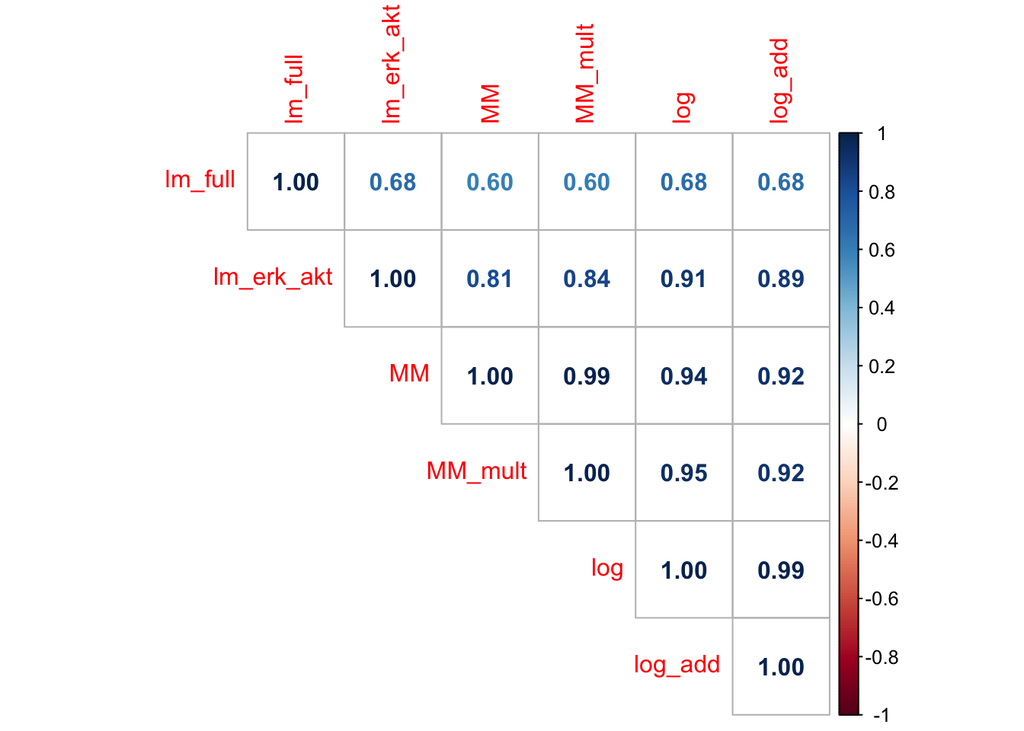

```r
mat <- loo_results %>%
  select(Cell, Treatment, model, PredictedViability) %>%
  spread(model, PredictedViability) %>%
  select(-Cell, -Treatment) %>%
  as.matrix() %>%
  cor(method = 'pearson')



corrplot::corrplot(mat, method="number", type="upper", order="hclust")
```

```r
pdf(file = here("figures/correlations-and-predictions/models-correlation-matrix.pdf"))
corrplot::corrplot(mat, method="number", type="upper", order="hclust")
dev.off()
```

# Final model selection: Michaelis-Menten-like transfer functions

Based on the cross-validated prediction performance, we selected to use the Michaelis-menten like transfer function.

$$\mathrm{viability} \sim \frac{1}{1 -
\Delta ERK1/KM_{ERK1} - \Delta AKT/KM_{AKT}}$$

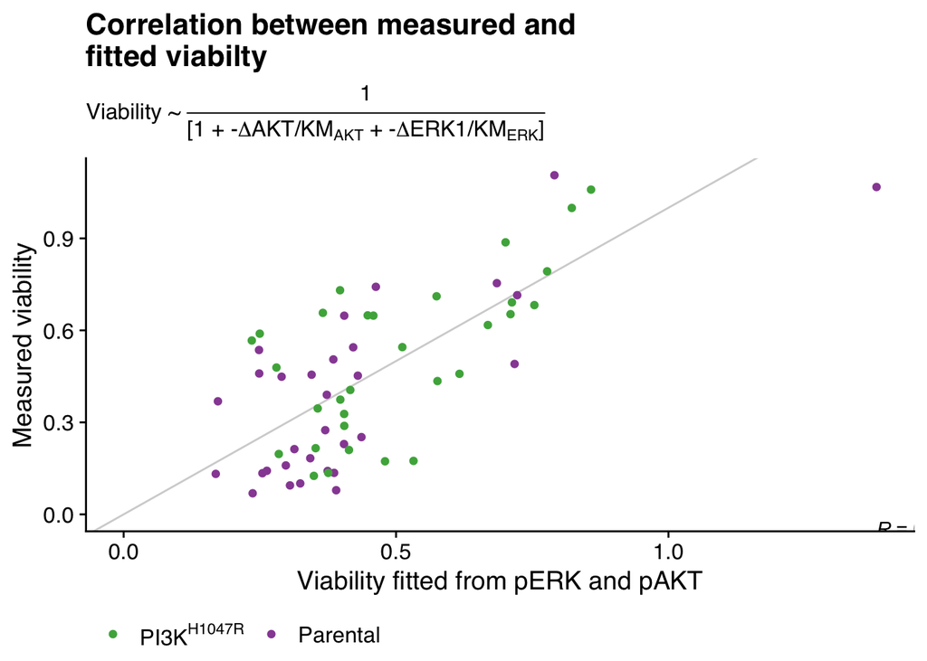

```r
# subtitle_mm <- expression(
#   "Viability ~ " * frac("1","[1 + -"*Delta*"AKT/KM"[AKT] * " + -"
#   * Delta*"ERK1/KM"[ERK] * "]"))
#
# formula_mm  <- Viability ~ (1/(1 + -ERK1 / KM_ERK1 + -BioAkt / KM_BioAkt))
#
# fit_mm_wt  <- nls(
#   formula_mm, filter(dat_lfc, Cell == "WT"),
#   start = list("KM_ERK1" = 0.5, "KM_BioAkt" = 2.5)
#   )
#
# fit_mm_pi3k  <- nls(
#   formula_mm, filter(dat_lfc, Cell == "PI3K"),
#   start = list("KM_ERK1" = 0.5, "KM_BioAkt" = 2.5)
#   )

tmp <- bind_rows(
  "PI3K" = broom::augment(fit_mm_pi3k), "WT" = broom::augment(fit_mm_wt),
  .id = "Cell"
  ) %>%
  #filter(.fitted < 1.) %>%
  select(Cell, Viability, .fitted, .resid)

prediction_wt <- broom::augment(fit_mm_wt, filter(dat_lfc, Cell == "WT")) %>%
  rename(PredictedViability = .fitted)

prediction_pi3k <- broom::augment(fit_mm_pi3k, filter(dat_lfc, Cell == "PI3K")) %>%
  rename(PredictedViability = .fitted)


prediction_combined <- bind_rows(prediction_wt, prediction_pi3k)
tmp2 <- select(prediction_combined, Cell, Viability, .fitted = PredictedViability, .resid)

ggplot(prediction_combined,
  aes(x = Viability, y = PredictedViability)) +
  geom_abline(slope = 1, color = "lightgray") +
  geom_point(aes(color = Cell)) +
  #geom_smooth(method = "lm") +
  labs(
    title = "Correlation between measured and\nfitted viabilty",
    subtitle = subtitle_mm,
    x = "Measured viability", y = "Viability fitted from pERK and pAKT"
  ) +
  expand_limits(x = 0, y = 0) +
  coord_flip() +
  ggpubr::stat_cor(method = "pearson") +
  scale_color_manual(name = "", values = color_lst, labels = label_lst) +
  cowplot::theme_cowplot(font_family = "Helvetica") +
  theme(legend.position = "bottom")
```

```r
ggsave(here('figures', 'correlations-and-predictions', 'viability-signaling-MM-all.pdf'),
       width=2, height=2)
```

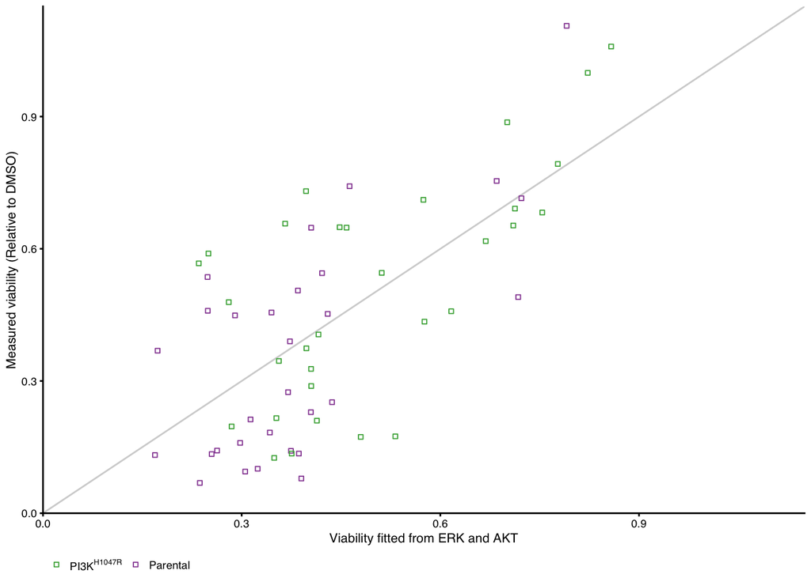

```r
ggplot(prediction_combined,
  aes(x = Viability, y = PredictedViability)) +
  geom_abline(slope = 1, color = "lightgray") +
  geom_point(aes(color = Cell), size=1, shape=0) +
  labs(
    # title = "Correlation between measured and\nfitted viabilty",
    # subtitle = subtitle_mm,
    x = "Measured viability (Relative to DMSO)", y = "Viability fitted from ERK and AKT"
  ) +
  scale_x_continuous(expand = c(0, 0), limits = c(0,1.15)) +
  scale_y_continuous(expand = c(0, 0), limits = c(0, 1.15))+
  # #xlim(c(0, 1.15)) + ylim(c(0, 1.5)) +
  # ggpubr::stat_cor(method = "pearson") +
  scale_color_manual(name = "", values = color_lst, labels = label_lst) +
  cowplot::theme_cowplot(font_family = "Helvetica", font_size = 8) +
  coord_flip() +
  theme(legend.position = "bottom")
```

```r
ggsave(here('figures', 'correlations-and-predictions', 'viability-signaling-MM-all.pdf'),
        width=60/inch2mm, height = 60/inch2mm)
tmp <- bind_rows(
  "PI3K" = broom::augment(fit_mm_pi3k), "WT" = broom::augment(fit_mm_wt),
  .id = "Cell"
  )
```

We obtain the following parameters from this.

```r
params <- bind_rows(
  list("WT" = broom::tidy(fit_mm_wt),
       "PI3K" = broom::tidy(fit_mm_pi3k)),
  .id = "Cell"

)

params
```

| Cell | term | estimate | std.error | statistic | p.value |
| --- | --- | --- | --- | --- | --- |
| WT | KM_ERK1 | 0.7930689 | 0.1633602 | 4.854725 | 3.798304e-05 |
| WT | KM_BioAkt | 6.0325021 | 2.1772362 | 2.770716 | 9.659919e-03 |
| PI3K | KM_ERK1 | 0.9768651 | 0.2276741 | 4.290629 | 1.808095e-04 |
| PI3K | KM_BioAkt | 4.5329303 | 1.9770195 | 2.292810 | 2.930124e-02 |

```r
write_tsv(params,
          here('results', 'perturbations', 'signaling-viability-parameters.tsv')
)
```

## Parameter uncertainty estimation using bootstrapping

The model fits the data fairly well. To perform parameter uncertainty estimation, and asses to what extend the parameters might differ between the cell lines, we perform 1000 bootstraps.

```r
boot_wt <-
  dat_lfc %>%
  filter(Cell == "WT") %>%
  rsample::bootstraps(times = 1000) %>%
  pull(splits) %>%
  map(
    possibly(
      function(split) {
        nls(formula = formula_mm,
            data = rsample::analysis(split),
            start = list("KM_ERK1" = 0.6, "KM_BioAkt" = 3.9)) %>%
          broom::tidy() %>%
          select(term, estimate) %>%
          spread(term, estimate)
      },
      otherwise = tibble(KM_BioAkt = NA, KM_ERK1 = NA)
    )
  ) %>%
  bind_rows(.id = "bootstrap")

boot_pi3k <-
  dat_lfc %>%
  filter(Cell == "PI3K") %>%
  rsample::bootstraps(times = 1000) %>%
  pull(splits) %>%
  map(
    possibly(
      function(split) {
        nls(formula = formula_mm,
            data = rsample::analysis(split),
            start = list("KM_ERK1" = 0.6, "KM_BioAkt" = 3.9)) %>%
          broom::tidy() %>%
          select(term, estimate) %>%
          spread(term, estimate)
      },
      otherwise = tibble(KM_BioAkt = NA, KM_ERK1 = NA)
    )
  ) %>%
  bind_rows(.id = "bootstrap")

boot_results <- bind_rows(
  list( "WT" = boot_wt, "PI3K" = boot_pi3k),
  .id = "model")
```

The plot below shows the 95% confidence intervals of the parameters overlap between the cell lines.

```r
tmp <- gather(boot_results, term, estimate, KM_BioAkt, KM_ERK1) %>%
  group_by(model, term) %>%
  summarise(
    median = median(estimate, na.rm = TRUE),
    mean = mean(estimate, na.rm = TRUE),
    ci_lower = quantile(estimate, probs = 0.025, na.rm = TRUE),
    ci_upper = quantile(estimate, probs = 0.975, na.rm = TRUE)
  )
```

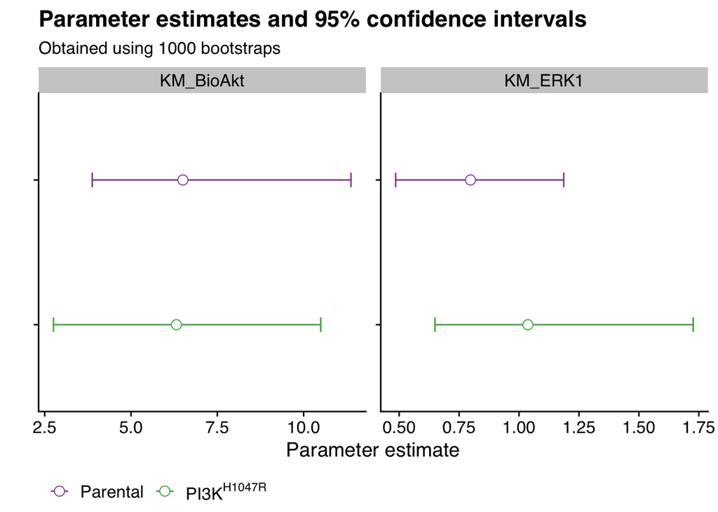

```r
plt <- ggplot(filter(tmp, model != "combined"), aes(x = model, y = mean, color = model)) +
  geom_errorbar(aes(ymin = ci_lower, ymax = ci_upper), width = .1) +
  geom_point(size = 3, shape = 21, fill = "white") +
  facet_wrap(~term, scales = "free", ncol = 4) +
  coord_flip() +
  scale_color_manual(name = "", breaks = c("WT", "PI3K"),
                     values = color_lst,
                     labels = label_lst
  ) +
  cowplot::theme_half_open(font_family = "Helvetica") +
  theme(legend.position = "bottom", axis.text.y =element_blank()) +
  labs(y = "Parameter estimate", x = "",
       title = "Parameter estimates and 95% confidence intervals",
       subtitle = "Obtained using 1000 bootstraps"
  )
plt
```

# Conclusion

- The phenotypic response (Viability) can be predicted well from the measured signaling responses. This is surprising as signaling is measured after 2 hours, whereas viability is a 3-day assay.
- Changes in ERK1 and AKT1 are most informative.
- Non-linear transfer functions have better performance than linear ones (with similar or more number of parameters). The “Michaelis-Menten”-like functions gives the best performance (but other non-linear functions give very similar results).